# Modes of the Ball-Channel Pendulum Linear Model

```python
import numpy as np
import numpy.linalg as la
import matplotlib.pyplot as plt
from resonance.linear_systems import BallChannelPendulumSystem
```

```python
%matplotlib inline
```

A (almost) premade system is available in `resonance`. The only thing missing is the function that calculates the canonical coefficients.

```python
sys = BallChannelPendulumSystem()
```

```python
sys.constants
```

```
{'mp': 0.012, 'mb': 0.0035, 'r': 0.1, 'l': 0.2, 'g': 9.81}
```

```python
sys.states
```

```
{'theta': 0.17453292519943295, 'phi': -0.17453292519943295, 'alpha': 0.0, 'beta': 0.0}
```

```python
def can_coeffs(mp, mb, l, g, r):
    M = np.array([[mp * l**2 + mb * r**2, -mb * r**2],
                  [-mb * r**2, mb * r**2]])
    C = np.zeros((2, 2))
    K = np.array([[g * l * mp, g * mb * r],
                  [g * mb * r, g * mb * r]])
    return M, C, K
```

```python
sys.canonical_coeffs_func = can_coeffs
```

Once the system is completely defined the mass, damping, and stiffness matrices can be calculated and inspected:

```python
M, C, K = sys.canonical_coefficients()
```

```python
M
```

```
array([[ 5.15e-04, -3.50e-05],
       [-3.50e-05,  3.50e-05]])
```

```python
C
```

```
array([[0., 0.],
       [0., 0.]])
```

```python
K
```

```
array([[0.023544 , 0.0034335],
       [0.0034335, 0.0034335]])
```

## Convert to mass normalized form (calculate $\tilde{\mathbf{K}}$)

First calculate the Cholesky lower triangular decomposition matrix of $\mathbf{M}$, which is symmetric and postive definite.

```python
L = la.cholesky(M)
L
```

```
array([[ 0.02269361,  0.        ],
       [-0.00154228,  0.00571151]])
```

The transpose can be computed with `np.transpose()`, `L.transpose()` or `L.T` for short:

```python
np.transpose(L)
```

```
array([[ 0.02269361, -0.00154228],
       [ 0.        ,  0.00571151]])
```

```python
L.transpose()
```

```
array([[ 0.02269361, -0.00154228],
       [ 0.        ,  0.00571151]])
```

```python
L.T
```

```
array([[ 0.02269361, -0.00154228],
       [ 0.        ,  0.00571151]])
```

Check that $\mathbf{L}\mathbf{L}^T$ returns $M$. Note that in Python the `@` operator is used for matrix multiplication. The `*` operator will do elementwise multiplication.

```python
L @ L.T
```

```
array([[ 5.15e-04, -3.50e-05],
       [-3.50e-05,  3.50e-05]])
```

`inv()` computes the inverse, giving $\left(\mathbf{L}^T\right)^{-1}$:

```python
la.inv(L.T)
```

```
array([[ 44.06526492,  11.89898149],
       [  0.        , 175.08501336]])
```

$\mathbf{L}^{-1}\mathbf{M}\left(\mathbf{L}^T\right)^{-1} = \mathbf{I}$. Note that the off-diagonal terms are very small numbers. The reason these are not precisely zero is due to floating point arithmetic and the associated truncation errors.

```python
la.inv(L) @ M @ la.inv(L.T)
```

```
array([[ 1.00000000e+00, -1.82171447e-17],
       [-1.16059609e-17,  1.00000000e+00]])
```

$\tilde{\mathbf{K}} = \mathbf{L}^{-1}\mathbf{K}\left(\mathbf{L}^T\right)^{-1}$. Note that this matrix is symmetric. It is guaranteed to be symmetric if $\mathbf{K}$ is symmetric.

```python
Ktilde = la.inv(L) @ K @ la.inv(L.T)
Ktilde
```

```
array([[ 45.71650485,  38.83489484],
       [ 38.83489484, 122.89287015]])
```

The entries of $\tilde{\mathbf{K}}$ can be accessed as so:

```python
k11 = Ktilde[0, 0]
k12 = Ktilde[0, 1]
k21 = Ktilde[1, 0]
k22 = Ktilde[1, 1]
```

# Calculate the eigenvalues of $\tilde{\mathbf{K}}$

The eigenvalues of this 2 x 2 matrix are found by forming the characteristic equation from:

$$\textrm{det}\left(\tilde{\mathbf{K}} - \lambda \mathbf{I}\right) = 0$$

and solving the resulting quadratic polynomial for its roots, which are the eigenvalues.

```python
lam1 = (k11 + k22) / 2 + np.sqrt((k11 + k22)**2 - 4 * (k11 * k22 - k12*k21)) / 2
lam1
```

```
139.05134855775452
```

```python
lam2 = (k11 + k22) / 2 - np.sqrt((k11 + k22)**2 - 4 * (k11 * k22 - k12*k21)) / 2
lam2
```

```
29.558026442245463
```

# Calculate the eigenfrequencies of the system

$\omega_i = \sqrt{\lambda_i}$

```python
omega1 = np.sqrt(lam1)
omega1
```

```
11.792003585385926
```

```python
omega2 = np.sqrt(lam2)
omega2
```

```
5.436729388358912
```

And in Hertz:

```python
fn1 = omega1/2/np.pi
fn1
```

```
1.876755659571523
```

```python
fn2 = omega2/2/np.pi
fn2
```

```
0.8652823564102976
```

# Calculate the eigenvectors of $\tilde{\mathbf{K}}$

The eigenvectors can be found by substituting the value for $\lambda$ into:

$$\tilde{\mathbf{K}}\hat{q}_0 = \lambda \hat{q}_0$$

and solving for $\hat{q}_0$.

```python
v1 = np.array([-k12 / (k11 - lam1), 1])
```

```python
v2 = np.array([-k12 / (k11 - lam2), 1])
```

Check that they are orthogonal, i.e. the dot product should be zero.

```python
np.dot(v1, v2)
```

```
2.220446049250313e-16
```

The `norm()` function calculates the Euclidean norm, i.e. the vector's magnitude and the vectors can be normalized like so:

```python
v1_hat = v1 / np.linalg.norm(v1)
v2_hat = v2 / np.linalg.norm(v2)
```

```python
v1_hat
```

```
array([0.38415493, 0.92326864])
```

```python
v2_hat
```

```
array([-0.92326864,  0.38415493])
```

```python
np.linalg.norm(v1_hat)
```

```
1.0
```

For any size $\tilde{\mathbf{K}}$ the `eig()` function can be used to calculate the eigenvalues and the normalized eigenvectors with one function call:

```python
evals, evecs = np.linalg.eig(Ktilde)
```

```python
evals
```

```
array([ 29.55802644, 139.05134856])
```

```python
evecs
```

```
array([[-0.92326864, -0.38415493],
       [ 0.38415493, -0.92326864]])
```

The columns of `evecs` correspond to the entries of `evals`.

```python
P = evecs
P
```

```
array([[-0.92326864, -0.38415493],
       [ 0.38415493, -0.92326864]])
```

If P contains columns that are orthnormal, then $\mathbf{P}^T \mathbf{P} = \mathbf{I}$. Check this with:

```python
P.T @ P
```

```
array([[1., 0.],
       [0., 1.]])
```

$\mathbf{P}$ can be used to find the matrix $\Lambda$ that decouples the differential equations.

```python
Lam = P.T @ Ktilde @ P
Lam
```

```
array([[ 2.95580264e+01, -5.32907052e-15],
       [ 0.00000000e+00,  1.39051349e+02]])
```

# Formulate solution to ODEs (simulation)

The trajectory of the coordinates can be found with:

$$ \bar{c}(t) = \sum_{i=1}^n c_i \sin(\omega_i t + \phi_i) \bar{u}_i $$

where

$$ \phi_i = \arctan \frac{\omega_i \hat{q}_{0i}^T \bar{q}(0)}{\hat{q}_{0i}^T \dot{\bar{q}}(0)} $$

and

$$ c_i = \frac{\hat{q}^T_{0i} \bar{q}(0)}{\sin\phi_i} $$

$c_i$ are the modal participation factors and reflect what propotional of each mode is excited given specific initial conditions. If the initial conditions are the eigenmode, $\bar{u}_i$, the all but the $i$th $c_i$ will be zero.

```python
S = la.inv(L.T) @ P
S
```

```
array([[ -36.11302491,  -27.9138454 ],
       [  67.25977163, -161.6505027 ]])
```

```python
u1 = S[:, 0]
u2 = S[:, 1]
```

```python
u1
```

```
array([-36.11302491,  67.25977163])
```

```python
u2
```

```
array([ -27.9138454, -161.6505027])
```

Define the initial coordinates as a scalar factor of the second eigenvector, which sets these values to small angles.

```python
c0 = S[:, 1] / 400
np.rad2deg(c0)
```

```
array([ -3.99836383, -23.1547289 ])
```

Set the initial speeds to zero:

```python
s0 = np.zeros(2)
s0
```

```
array([0., 0.])
```

The initial mass normalized coordinates and speeds are then:

```python
q0 = L.T @ c0
q0
```

```
array([-0.00096039, -0.00230817])
```

```python
qd0 = L.T @ s0
qd0
```

```
array([0., 0.])
```

Calculate the modal freqencies in radians per second.

```python
ws = np.sqrt(evals)
ws
```

```
array([ 5.43672939, 11.79200359])
```

The phase shifts for each mode can be found. Note that it is important to use `arctan2()` so that the quadrant and thus sign of the arc tangent is properly handled.

$$ \phi_i = \arctan \frac{\omega_i \hat{q}_{0i}^T \bar{q}(0)}{\hat{q}_{0i}^T \dot{\bar{q}}(0)} $$

```python
phi1 = np.arctan2(ws * P[:, 0] @ q0, P[:, 0] @ qd0)
phi1
```

```
-1.5707963267948966
```

```python
phi2 =  np.arctan2(ws * P[:, 1] @ q0, P[:, 1] @ qd0)
phi2
```

```
1.5707963267948966
```

All $\phi$'s can be calculated in one line using NumPy's broadcasting feature:

```python
phis = np.arctan2(ws * P.T @ q0, P.T @ qd0)
phis
```

```
array([-1.57079633,  1.57079633])
```

The phase shifts for this particular initial condition are $\pm90$ degrees.

```python
np.rad2deg(phis)
```

```
array([-90.,  90.])
```

Now calculate the modal participation factors.

$$ c_i = \frac{\hat{q}^T_{0i} \bar{q}(0)}{\sin\phi_i} $$

```python
cs = P.T @ q0 / np.sin(phis)
cs
```

```
array([-0.    ,  0.0025])
```

Note that the first participation factor is zero. This is because we've set the initial coordinate to be a scalar function of the second eigenvector.

## Simulate

```python
t = np.linspace(0, 5, num=500)
```

```python
cs[1] * np.sin(ws[1] * t)
```

[output not shown]

[output cut: 70 more lines]

[output not shown]

The following line will give an error because the dimensions of `u1` are not compatible with the dimensions of the preceding portion. It is possible for a single line to work like this if you take advatnage of NumPy's broadcasting rules. See https://scipy-lectures.org/intro/numpy/operations.html#broadcasting for more info. The `tile()` function is used to repeat `u1` as many times as needed.

```python
# cs[1] * np.sin(ws[1] * t) * u1
```

```python
c1 = cs[1] * np.sin(ws[1] * t) * np.tile(u1, (len(t), 1)).T
c1.shape
```

```
(2, 500)
```

Now use a loop to calculate the contribution of each mode and build the summation of contributions from each mode:

```python
ct = np.zeros((2, len(t)))  # 2 x m array to hold coordinates as a function of time
for ci, wi, phii, ui in zip(cs, ws, phis, S.T):
    print(ci, wi, phii, ui)
    ct += ci * np.sin(wi * t + phii) * np.tile(ui, (len(t), 1)).T
```

```
-0.0 5.436729388358913 -1.5707963267948966 [-36.11302491  67.25977163]
0.0025000000000000005 11.792003585385926 1.5707963267948966 [ -27.9138454 -161.6505027]
```

```python
def sim(c0, s0, t):
    """Returns the time history of the coordinate vector, c(t) given the initial state and time.

    Parameters
    ==========
    c0 : ndarray, shape(n,)
    s0 : ndarray, shape(n,)
    t : ndarray, shape(m,)

    Returns
    =======
    c(t) : ndarray, shape(n, m)

    """
    q0 = L.T @ c0
    qd0 = L.T @ s0
    ws = np.sqrt(evals)
    phis = np.arctan2(ws * P.T @ q0, P.T @ qd0)
    cs = P.T @ q0 / np.sin(phis)
    c = np.zeros((2, 1000))
    for ci, wi, phii, ui in zip(cs, ws, phis, S.T):
        c += ci * np.sin(wi * t + phii) * np.tile(ui, (len(t), 1)).T
    return c
```

Simulate and plot the first mode:

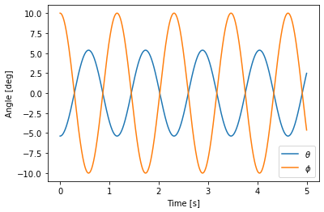

```python
t = np.linspace(0, 5, num=1000)

c0 = S[:, 0] / np.max(S[:, 0]) * np.deg2rad(10)
s0 = np.zeros(2)

fig, ax = plt.subplots()
ax.plot(t, np.rad2deg(sim(c0, s0, t).T))
ax.set_xlabel('Time [s]')
ax.set_ylabel('Angle [deg]')
ax.legend([r'$\theta$', r'$\phi$'])
```

Simulate and plot the second mode:

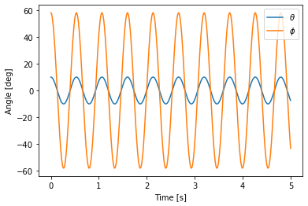

```python
t = np.linspace(0, 5, num=1000)

c0 = S[:, 1] / np.max(S[:, 1]) * np.deg2rad(10)
s0 = np.zeros(2)

fig, ax = plt.subplots()
ax.plot(t, np.rad2deg(sim(c0, s0, t).T))
ax.set_xlabel('Time [s]')
ax.set_ylabel('Angle [deg]')
ax.legend([r'$\theta$', r'$\phi$'])
```

Compare this to the free response from the system:

```python
sys.coordinates['theta'] = c0[0]
sys.coordinates['phi'] = c0[1]

sys.speeds['alpha'] = 0
sys.speeds['beta'] = 0
```

```python
traj = sys.free_response(5.0)
```

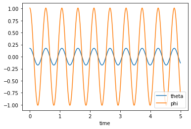

```python
traj[['theta', 'phi']].plot()
```

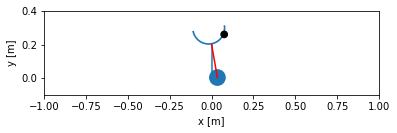

```python
sys.animate_configuration(fps=30, repeat=False)
```

Simulate with arbitrary initial conditions.

```python
sys.coordinates['theta'] = np.deg2rad(12.0)
sys.coordinates['phi'] = np.deg2rad(3.0)
traj = sys.free_response(5.0)
```

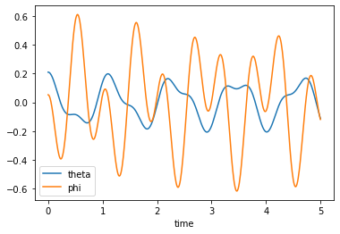

```python
traj[['theta', 'phi']].plot()
```